# Case Study 1

### Next, we decide to use a KNN classification model to investigate the relationship between IBU and ABV in IPAs and other types of Ales.

```r
#first, we create the data frames to be able to create the models.

sum(grepl("Ale", join$Style))
```

```
## [1] 559
```

```r
sum(grepl("(India | IPA)", join$Style))
```

```
## [1] 395
```

```r
IPAs <- join %>% filter(grepl("(India | IPA)", Style)) %>% filter(!grepl("Lager", Style))
Ales <- join %>% filter(grepl("Ale", Style)) %>% filter(!grepl("(India | IPA)", Style))

x <- data.frame(Group = "Ale", c(1:552)) %>% select(Group)
final_Ales <- cbind(x, Ales)

y <- data.frame(Group = "IPA", c(1:392)) %>% select(Group)
final_IPAs <- cbind(y, IPAs)

IPA_Ales <- full_join(final_IPAs, final_Ales)
```

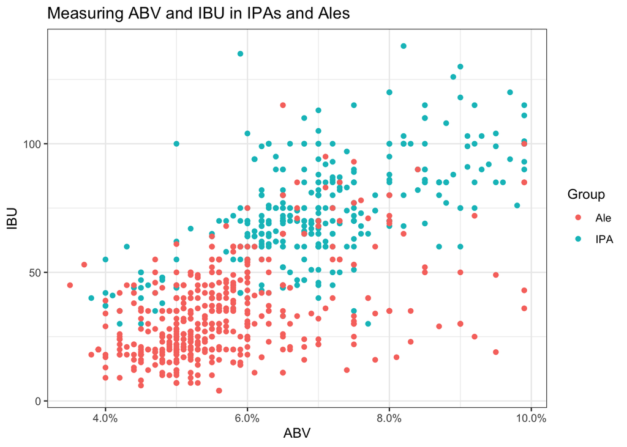

```r
# We plot the data to get visually acquainted and double check the data. All looks well, moving on.
IPA_Ales %>% ggplot(aes(x = ABV, y = IBU, color = Group)) +
  geom_point() +
  scale_x_continuous(labels = scales::percent) +
  theme_bw() +
  ggtitle("Measuring ABV and IBU in IPAs and Ales")
```

```r
# knn model. We first run a simple internal validation model to determine the accuracy of the model with k = 3.

confusionMatrix(table(knn.cv(IPA_Ales[,8:9], IPA_Ales$Group, k = 3), IPA_Ales$Group))
```

```
## Confusion Matrix and Statistics
##
##
##       Ale IPA
##   Ale 485  70
##   IPA  67 322
##
##                Accuracy : 0.8549
##                  95% CI : (0.8308, 0.8767)
##     No Information Rate : 0.5847
##     P-Value [Acc > NIR] : <2e-16
##
##                   Kappa : 0.7008
##
##  Mcnemar's Test P-Value : 0.8643
##
##             Sensitivity : 0.8786
##             Specificity : 0.8214
##          Pos Pred Value : 0.8739
##          Neg Pred Value : 0.8278
##              Prevalence : 0.5847
##          Detection Rate : 0.5138
##    Detection Prevalence : 0.5879
##       Balanced Accuracy : 0.8500
##
##        'Positive' Class : Ale
##
```

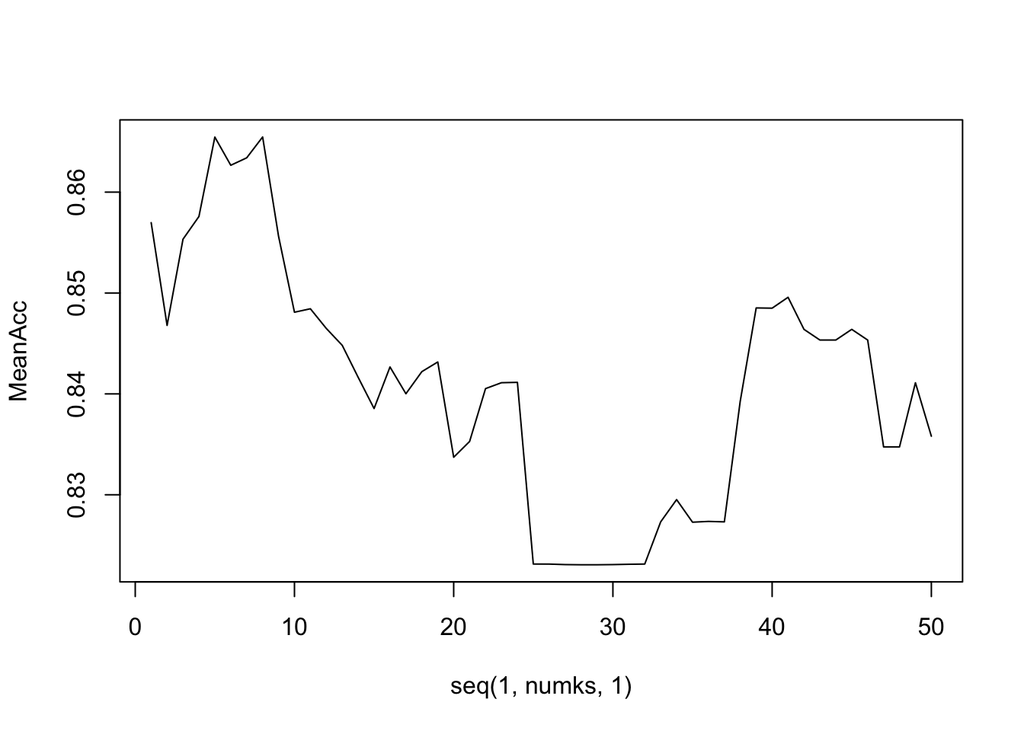

```r
#We must establish the optimal number for k, with regards to accuracy. This runs all the k's from 1-50 five hundred times and plots the averages for each.

set.seed(1)
iterations = 500
numks = 50

masterAcc = matrix(nrow = iterations, ncol = numks)

for(j in 1:iterations)
{

  for(i in 1:numks)
  {
    CM = confusionMatrix(table(IPA_Ales$Group, knn.cv(IPA_Ales[,8:9], IPA_Ales$Group, k = i)))
    masterAcc[j,i] = CM$overall[1]

  }

}

MeanAcc = colMeans(masterAcc)

plot(seq(1,numks,1),MeanAcc, type = "l")
```

```r
which.max(MeanAcc)
```

```
## [1] 8
```

```r
max(MeanAcc)
```

```
## [1] 0.8654661
```

```r
confusionMatrix(table(IPA_Ales$Group, knn.cv(IPA_Ales[,8:9], IPA_Ales$Group, k = 8)))
```

```
## Confusion Matrix and Statistics
##
##
##       Ale IPA
##   Ale 498  54
##   IPA  71 321
##
##                Accuracy : 0.8676
##                  95% CI : (0.8443, 0.8886)
##     No Information Rate : 0.6028
##     P-Value [Acc > NIR] : <2e-16
##
##                   Kappa : 0.7256
##
##  Mcnemar's Test P-Value : 0.1524
##
##             Sensitivity : 0.8752
##             Specificity : 0.8560
##          Pos Pred Value : 0.9022
##          Neg Pred Value : 0.8189
##              Prevalence : 0.6028
##          Detection Rate : 0.5275
##    Detection Prevalence : 0.5847
##       Balanced Accuracy : 0.8656
##
##        'Positive' Class : Ale
##
```

##### Although we checked accuracy based on multiple iterations, we report on a single run using a specific seed for reproducibility.

##### The overall accuracy of our internal KNN classification model was 86.8%.

##### Given no information and guessing all classifications to be other Ales, accuracy was 60.28%

##### The sensitivity, or the model’s ability to accurately classify other Ales, was 87.5%.

##### The specificity, or the model’s ability to accurately classify IPAs, was 85.6%.

### Additional insights from exploring the data.

#### We explored the possibility of creating a Naive Bayes model which predicts the preference of a state for IPAs or Ales.

```r
#Naive Bayes
nbIPA_Ales <- IPA_Ales %>% select(Group, ABV, IBU)
naiveBayes(Group~., data = nbIPA_Ales )
```

```
##
## Naive Bayes Classifier for Discrete Predictors
##
## Call:
## naiveBayes.default(x = X, y = Y, laplace = laplace)
##
## A-priori probabilities:
## Y
##       Ale       IPA
## 0.5847458 0.4152542
##
## Conditional probabilities:
##      ABV
## Y           [,1]       [,2]
##   Ale 0.05655616 0.01112430
##   IPA 0.06914286 0.01216069
##
##      IBU
## Y         [,1]     [,2]
##   Ale 34.33333 17.97471
##   IPA 71.94898 19.54567
```

```r
iterations = 100
masterAcc = matrix(nrow = iterations)
splitPerc = .8 #Training / Test split Percentage
for(j in 1:iterations)
{
  trainIndices = sample(1:dim(nbIPA_Ales)[1],round(splitPerc * dim(nbIPA_Ales)[1]))
  train = nbIPA_Ales[trainIndices,]
  test = nbIPA_Ales[-trainIndices,]
  model = naiveBayes(train[,2:3],train$Group)
  table(test$Group,predict(model,test[,2:3]))
  CM = confusionMatrix(table(test$Group,predict(model,test[,2:3])))
  masterAcc[j] = CM$overall[1]
}
MeanAcc = colMeans(masterAcc)
MeanAcc
```

```
## [1] 0.8419577
```

#### The model was able to predict IPA:Ale classification based on ABV and IBU inputs.

#### Next, we run a simple independent sample Welch’s t-test for both ABV and IBU to determine if there’s a significant difference between the groups in those metrics.

```r
### t-test
Ales_ABV <- final_Ales %>% select(ABV, Group)
IPAs_ABV <- final_IPAs %>% filter(!grepl("Lager", Style)) %>% select(ABV, Group)

ABVjoin <- full_join(Ales_ABV, IPAs_ABV)
t.test(log(ABV) ~ Group, data = ABVjoin)
```

```
##
##  Welch Two Sample t-test
##
## data:  log(ABV) by Group
## t = -16.91, df = 849.95, p-value < 2.2e-16
## alternative hypothesis: true difference in means between group Ale and group IPA is not equal to 0
## 95 percent confidence interval:
##  -0.2260548 -0.1790364
## sample estimates:
## mean in group Ale mean in group IPA
##         -2.889941         -2.687395
```

```r
t.test(IBU ~ Group, data = IPA_Ales)
```

```
##
##  Welch Two Sample t-test
##
## data:  IBU by Group
## t = -30.118, df = 797.55, p-value < 2.2e-16
## alternative hypothesis: true difference in means between group Ale and group IPA is not equal to 0
## 95 percent confidence interval:
##  -40.06727 -35.16402
## sample estimates:
## mean in group Ale mean in group IPA
##          34.33333          71.94898
```

#### In both t-tests the p-values were found to be <.0001, providing overwhelming evidence that the IPA group and the Ales group are not equal to each other in either ABV and IBU.

#### Here, we apply the same logic as the previous NB model.

```r
##For this NB model, we are able to predict IPA:Ale preference, by simply including a state as an input.

nb2 <- IPA_Ales %>% select(State, Group) %>% mutate(State = as.factor(State))
model <- naiveBayes(Group~., data = nb2)
predict(model, data.frame(State = "NH"), type = 'raw')
```

```
##            Ale       IPA
## [1,] 0.3556701 0.6443299
```

```r
###For this next NB model, we would like to extend the scope and predict preference of style of beer (all styles) given City and State as input.
df <- join %>% select(Style, City, State)
model <- naiveBayes(Style~., data = df)
predict(model, data.frame(State = "CO", City = "Buena Vista"))
```

```
## [1] American IPA
## 90 Levels: Abbey Single Ale Altbier ... Witbier
```

```r
###For this NB model, we do the same as the one above, predicting style, except only using State as input.
df2 <- df %>% select(Style, State)
model <- naiveBayes(Style~State, data = df2)
predict(model, data.frame(State = "CO"))
```

```
## [1] American Pale Ale (APA)
## 90 Levels: Abbey Single Ale Altbier ... Witbier
```

```r
### For this NB model, we would like to predict which city would a particular style of beer be most well received. This could be highly useful for marketing purposes.

df1 <- df %>% select(Style, City)
model <- naiveBayes(City~Style, data = df1)
pred <- predict(model, df1$Style)
CM <- confusionMatrix(as.factor(pred), as.factor(df1$City))
predict(model, data.frame(Style = "American IPA"))
```

```
## [1] San Diego
## 281 Levels: Abingdon Abita Springs Afton Albuquerque Anchorage ... York
```

```r
###This last NB similarly uses a Style of beer and predicts the State it would be most popular.

model <- naiveBayes(State~Style, data = df2)
pred <- predict(model, df2$Style)
CM <- confusionMatrix(as.factor(pred), as.factor(df2$State))
predict(model, data.frame(Style = "American IPA"))
```

```
## [1] CA
## 50 Levels: AK AL AR AZ CA CO CT DC DE FL GA HI IA ID IL IN KS KY LA MA ... WY
```

#### These Naive-Bayes models give us a lot to work with when it comes to marketing research and discovering geographic patterns for the data.

### We came across a website that was using ratings of beer to create a table for top rated beer per state and decided to clean up and provide a geographic visualization of each respective state’s highest-rated beer. Please see tableau visualizations.

```r
# Scraping website for Top Rated Beers by State data

content <- read_html("https://vinepair.com/articles/best-highest-rated-beer-every-state/")
tables <- content %>% html_table(fill = TRUE)
first_table <- tables[[1]]
first_table <- first_table[-1,]
topbeer <- first_table %>% rename(State = X1, Beer = X2)
topbeer <- topbeer %>% cbind(data.frame(state = state.abb[match(topbeer$State, state.name)]))
topbeer[is.na(topbeer)] <- "DC"
topbeer <- topbeer %>%
  select(state, Beer) %>%
  rename(State = state) %>%
  separate(Beer, into = c("Name", "Brewery", "Style"), sep = "\n") %>%
  separate(Style, into = c("Style", "ABV"), sep = "([|])")
head(topbeer)
```

```
##   State                         Name                       Brewery
## 1    AL                     El Gordo   Good People Brewing Company
## 2    AK                      Blessed     Anchorage Brewing Company
## 3    AZ White Russian Imperial Stout            Sun Up Brewing Co.
## 4    AR                         BDCS                Ozark Beer Co.
## 5    CA            Pliny The Younger Russian River Brewing Company
## 6    CO         Medianoche – Coconut         WeldWerks Brewing Co.
##                        Style     ABV
## 1  Stout – Russian Imperial   13.90%
## 2 Stout – American Imperial   14.00%
## 3 Stout – American Imperial    9.20%
## 4 Stout – American Imperial   10.20%
## 5            IPA – Imperial   10.25%
## 6 Stout – American Imperial   14.10%
```

```r
#Tableau Workbook URL: https://public.tableau.com/shared/4QFJCDFGZ?:display_count=n&:origin=viz_share_link
```